# Comparison of simulation to theory

Sun Feb 7 21:49:53 2016

Here's the things that we'd like to have plots of simulation compared to theory for, and might put in the paper:

1. **Establishment of the selected cline:** the frequency of the selected allele, $p(x,t)$, across space, at a few times.
2. **Conditional ancestry probabilities:** the conditional frequency of ancestry $A$ given being linked to a selected allele of ancestry $z$, denoted $q_z(x,t,r)$, across space, at a few times or distances and for each $z$.
3. **Relaxation of linked clines:** the frequency of ancestry $A$, denoted $p(x,t,r)$, across space, at a few times and one or two recombination distances. (This comes after $q$ because it is computed using $q$.)
4. **Haplotype probabilities:** the probability of seeing a haplotype of length at least $\ell$ covering position $r$ on the genome at location $x$ in space: for fixed $\ell$, against $r$ and/or $x$.

*Note:* This can be run as a script, by specifying `simchunks.file` first, and then rendering this document.

## Parameters from a simulation

We'll use some simulation results produced by yaniv_sims.R, and need to convert those parameters to those from theory. Dispersal in the simulation moves as $\lfloor Z + 1/2 \rfloor$, where $Z \sim N(0,\sigma^2_\text{demes})$; we'll use this fact to compute the actual $\sigma$. (Yes, that's an unbiased walk, thanks to the floor.) Migrants past the endpoints stay there (they don't reflect). We'll work in spatial units equal to one deme spacing; since generations are nonoverlapping, one generation is indeed one time step in the simulation.

```r
if (!exists("simchunks.file")) {
    simchunks.file <- "simulation_SIGMA1_Ninds25000_ndemes50_s0.1_tau100_run2016-01-11_simsums_chunks.Robj"
}
load(simchunks.file)  # provides 'chunks'
get_simparams <- function (fname) {
    strings <- c( sigma="SIGMA", ninds="Ninds", ndemes="ndemes", s="s", tau="tau" )
    lapply( strings, function (x) { as.numeric(gsub(sprintf(".*[/_]%s([0-9.]+)_.*",x),"\\1",simchunks.file)) } )
}
sim.params <- get_simparams( simchunks.file )
# recombination distances, hard-coded
sim.rvals <- c(0,0.01,0.5)
# spatial locations of the demes
xx <- seq_len(sim.params$ndemes)-(sim.params$ndemes+1)/2
theory.params <- list( sigma=trueSigma(sim.params$sigma), s=sim.params$s, tau=sim.params$tau,
       density=sim.params$ninds/sim.params$ndemes,
       width=sim.params$ndemes )
simchunks.file
```

```
## [1] "simulation_SIGMA1_Ninds5000_ndemes100_s0.1_dir/tau20_dir/results_simsums_chunks.Robj"
```

```r
unlist(theory.params)
```

```
##     sigma         s       tau   density     width
##   1.04058   0.10000  20.00000  50.00000 100.00000
```

*Note:* We should also work out what the actual value of **s** is.

Here are some functions we'll use to extract what we want from data in the `chunks` format:

```r
source("chunks_fns.R")
```

# Selected cline

To get the value predicted from theory, we'll solve the corresponding PDE:

```r
tt <- seq(0,theory.params$tau,length.out=21)
xgrid <- setup.grid.1D(x.up=-theory.params$width/2, x.down=theory.params$width/2, N=2*theory.params$width)
fgrid <- extend_grid(xgrid)
fwds.soln <- forwards_pde(s=theory.params$s, times=tt, grid=fgrid, sigma=theory.params$sigma )
```

... and, compare it to the observed values:

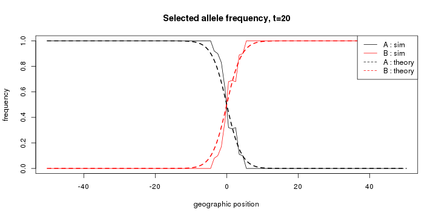

```r
gcounts <- genotype_counts(chunks[[1]])
# sim frequencies
sfreqs <- sweep( tcrossprod(gcounts,dip.to.hap), 1, 2*rowSums(gcounts), "/" )
# theory frequencies
tfreqs <- cbind( A=fwds.soln[nrow(fwds.soln),-1], B=1-fwds.soln[nrow(fwds.soln),-1] )
matplot(xx, sfreqs, type='l', lty=1, main=sprintf("Selected allele frequency, t=%d",sim.params$tau), ylab="frequency", xlab='geographic position')
matlines(fgrid$x.mid, tfreqs, lty=2, lwd=2)
legend("topright", legend=outer(colnames(sfreqs),c("sim","theory"),paste,sep=" : "), lty=rep(1:2,each=2), col=rep(1:ncol(sfreqs),2))
```

For fun, let's also look at genotype frequencies (is there HW?):

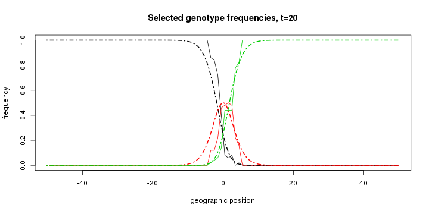

```r
matplot(xx, sweep(gcounts,1,rowSums(gcounts),"/"), lty=1, type='l', main=sprintf("Selected genotype frequencies, t=%d",sim.params$tau), ylab="frequency", xlab='geographic position')
matlines(fgrid$x.mid, cbind(AA=tfreqs[,"A"]^2,AB=2*tfreqs[,"A"]*tfreqs[,"B"],BB=tfreqs[,"B"]^2), lty=4, lwd=2)
```

**Note:** Verified by looking at simulations with small $\tau$, the shift in cline center is due to the cline drifting.

# Ancestry probabilities

First, compute theoretical predictions at the values of $r$ in the simulation:

```r
linked.solns <- lapply( sim.rvals, function (r) {
        forwards_backwards_pde(s=theory.params$s, times=tt, grid=xgrid, r=r,
                           sigma=theory.params$sigma, fwds.soln=fwds.soln, log.p=TRUE)
    } )
```

... and compare to the observed values:

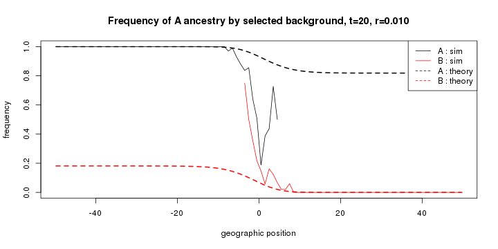

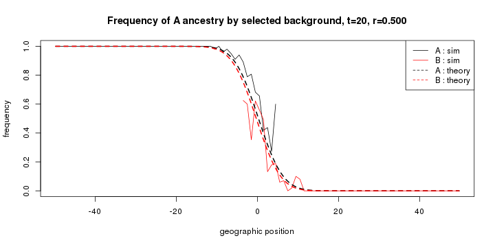

```r
for (kr in seq_along(sim.rvals)[-1]) {
    gcounts <- conditional_genotype_counts(chunks[[kr]], chunks[[1]])
    # frequencies from simulation
    cfreqs <- conditional_freqs(gcounts)
    # frequencies from theory
    tfreqs <- linked.solns[[kr]][nrow(linked.solns[[kr]]),-1]
    dim(tfreqs) <- c( length(xgrid$x.mid), 2 )
    matplot(xx, cfreqs, type='l', lty=1,
            main=sprintf("Frequency of A ancestry by selected background, t=%d, r=%0.3f",sim.params$tau, sim.rvals[kr]),
            ylab="frequency", xlab='geographic position')
    matlines(xgrid$x.mid, tfreqs, lty=2, lwd=2)
    legend("topright", legend=outer(colnames(cfreqs),c("sim","theory"),paste,sep=" : "), lty=rep(1:2,each=2), col=rep(1:ncol(sfreqs),2))
}
```

To help interpret this, here's the raw counts of the four phased haplotypes across the range: (labels are "linked-selected", for instance, "B-A" has B ancestry linked to the selected A allele)

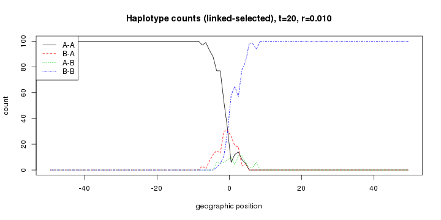

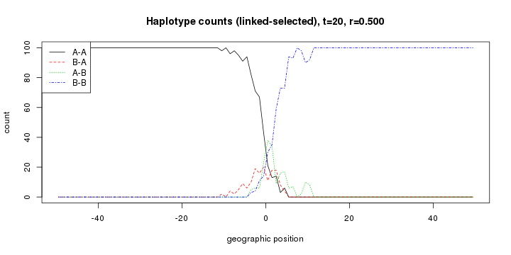

```r
for (kr in seq_along(sim.rvals)[-1]) {
    hcounts <- conditional_haplotype_counts( conditional_genotype_counts(chunks[[kr]], chunks[[1]]) )
    hc.names <- outer( dimnames(hcounts)[[2]], dimnames(hcounts)[[3]], paste, sep="-")
    dim(hcounts) <- c( dim(hcounts)[1], prod(dim(hcounts)[2:3]) )
    colnames(hcounts) <- hc.names
    matplot(xx, hcounts, type='l',
            main=sprintf("Haplotype counts (linked-selected), t=%d, r=%0.3f", sim.params$tau, sim.rvals[kr]),
            ylab="count", xlab="geographic position")
    legend('topleft', lty=1:5, col=1:6, legend=hc.names )
}
```

# Linked clines

This will just be a combination of the previous results, since it is local proportions of each type without conditioning on the allele at the selected locus.

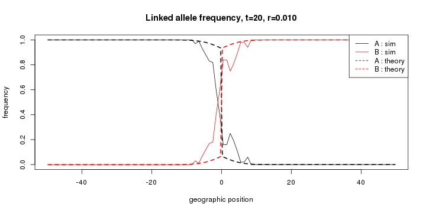

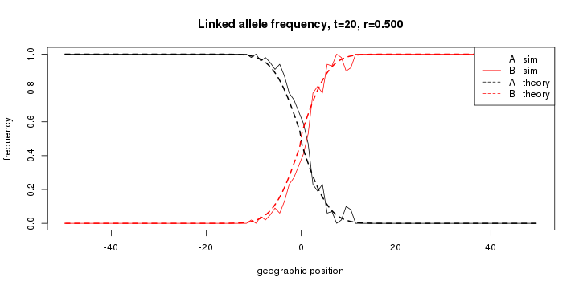

```r
for (kr in seq_along(sim.rvals)[-1]) {
    gcounts <- genotype_counts(chunks[[kr]])
    # sim frequencies
    sfreqs <- sweep( tcrossprod(gcounts,dip.to.hap), 1, 2*rowSums(gcounts), "/" )
    # theory frequencies
    cline.soln <- cline_from_soln(linked.solns[[kr]],grid=xgrid)
    tfreqs <- cbind( A=cline.soln[nrow(cline.soln),-1], B=1-cline.soln[nrow(cline.soln),-1] )
    matplot(xx, sfreqs, type='l', lty=1, main=sprintf("Linked allele frequency, t=%d, r=%0.3f",sim.params$tau, sim.rvals[kr]),
            ylab="frequency", xlab='geographic position')
    matlines(xgrid$x.mid, tfreqs, lty=2, lwd=2)
    legend("topright", legend=outer(colnames(sfreqs),c("sim","theory"),paste,sep=" : "), lty=rep(1:2,each=2), col=rep(1:ncol(sfreqs),2))
}
```